# FoodProject_Year

Arunima Awale

```r
library(tidyverse)
library(dplyr)
library(ggplot2)
```

Exploring differences in restaurant violations by year.

## Uploading the finalviol dataset

Starting by exploring the contents of the datset.

```r
summary(finalviol)
```

```
##        X            LICENSENO                  name
##  Min.   :     1   Min.   :  4032   Subway        :  1173
##  1st Qu.: 55773   1st Qu.: 21420   Dunkin Donuts :  1152
##  Median :111544   Median : 25121   Mcdonalds     :   822
##  Mean   :111544   Mean   : 48590   Dunkin' Donuts:   816
##  3rd Qu.:167316   3rd Qu.: 67870   Au Bon Pain   :   676
##  Max.   :223087   Max.   :379898   Burger King   :   649
##                                    (Other)       :217799
##                           DESCRIPT           ZIP            year
##  Eating & Drinking            :102258   Min.   :2050   Min.   :2006
##  Eating & Drinking w/ Take Out: 86013   1st Qu.:2115   1st Qu.:2010
##  Mobile Food Walk On          :  2261   Median :2122   Median :2013
##  Retail Food                  : 32555   Mean   :2128   Mean   :2013
##                                         3rd Qu.:2130   3rd Qu.:2016
##                                         Max.   :2467   Max.   :2018
##
##     LICSTATUS                                    violcats
##  Active  :148255   Food Equipment and Utensils       :49731
##  Deleted :    12   Floors, Walls, and Ceilings       :38450
##  Inactive: 74820   Food Protection                   :30427
##                    Toilet and hand-washing facilities:25969
##                    Others                            :20704
##                    Personnel                         :17433
##                    (Other)                           :40373
##  ViolStatus          n
##  Fail:117866   Min.   : 1.000
##  Pass:105221   1st Qu.: 1.000
##                Median : 1.000
##                Mean   : 2.286
##                3rd Qu.: 3.000
##                Max.   :64.000
##
```

```r
table(finalviol$year, finalviol$ViolStatus)
```

```
##
##         Fail  Pass
##   2006     0     2
##   2007  5498  6035
##   2008 10865  9459
##   2009  9928  8588
##   2010  8879  7657
##   2011  8669  7462
##   2012 10730  9585
##   2013  9781  8589
##   2014 10467  9310
##   2015 10426  9349
##   2016 11519 10489
##   2017 10177  8975
##   2018 10927  9721
```

Since there are only two observations for 2006, I’ve filtered out these observations from the subsequent analyses.

Looking at the trend in violation status of food inspections from 2007 to 2018, we see that there is a large jump in the number of food inspections that were conducted from 2007 to 2008. The number of food inspections declines between 2009 and 2011 and then picks up and remains fairly constant starting in 2012.

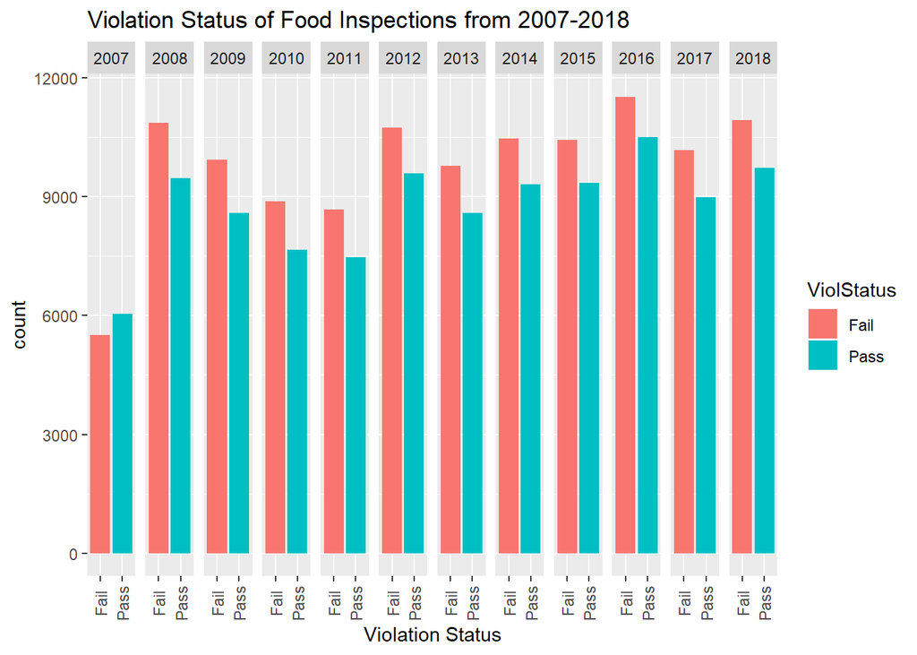

```r
finalviol %>% filter (year %in% c(2007,2008, 2009, 2010,2011, 2012, 2013, 2014, 2015, 2016, 2017,2018))%>% group_by(year) %>%

ggplot(aes(ViolStatus, fill=ViolStatus))+ geom_bar() +

  xlab ("Violation Status")+

  ggtitle("Violation Status of Food Inspections from 2007-2018")+

  theme(axis.text.x = element_text(angle = 90, vjust = 0.5))+

  facet_grid(.~year)
```

Throughout the years, around 53% of the food inspections have resulted in a Failed inspection.

```r
finalviol %>% filter (year !=2006) %>%

  group_by(year) %>%

  summarize(number_fail = sum(ViolStatus=="Fail"),number_pass =sum(ViolStatus=="Pass"),
            total =  n(), percent_fail=number_fail/total)
```

```
## # A tibble: 12 x 5
##     year number_fail number_pass total percent_fail
##    <int>       <int>       <int> <int>        <dbl>
##  1  2007        5498        6035 11533        0.477
##  2  2008       10865        9459 20324        0.535
##  3  2009        9928        8588 18516        0.536
##  4  2010        8879        7657 16536        0.537
##  5  2011        8669        7462 16131        0.537
##  6  2012       10730        9585 20315        0.528
##  7  2013        9781        8589 18370        0.532
##  8  2014       10467        9310 19777        0.529
##  9  2015       10426        9349 19775        0.527
## 10  2016       11519       10489 22008        0.523
## 11  2017       10177        8975 19152        0.531
## 12  2018       10927        9721 20648        0.529
```

```r
finalviol_year <- finalviol %>% filter (year !=2006) %>%

  group_by(year) %>%

  summarize(number_fail = sum(ViolStatus=="Fail"),number_pass =sum(ViolStatus=="Pass"),
            total =  n(), percent_fail=number_fail/total)
```

```r
finalviol_year %>% summarize(meanfail = mean(percent_fail))
```

```
## # A tibble: 1 x 1
##   meanfail
##      <dbl>
## 1    0.527
```

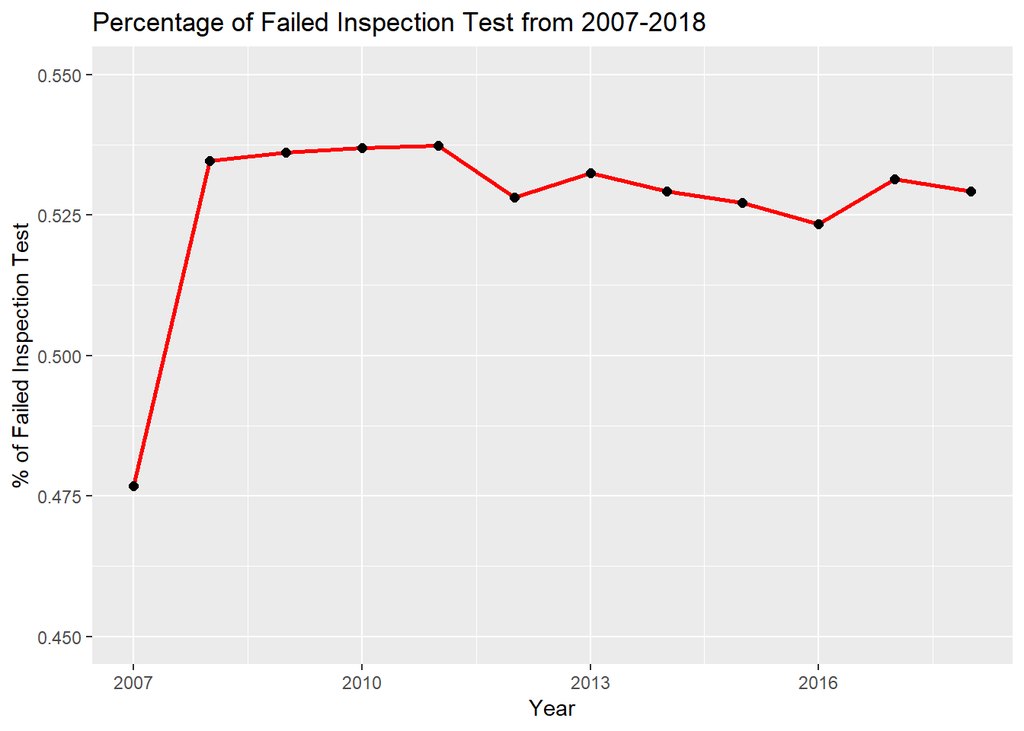

```r
finalviol_year %>% ggplot() +

  geom_line(aes (x=year, y=percent_fail), size = 1, color = "red")+

  ylim(0.45,0.55)+

  geom_point(aes (x=year, y=percent_fail), size = 2, color = "black")+

  xlab("Year")+

  ylab("% of Failed Inspection Test")+

  ggtitle("Percentage of Failed Inspection Test from 2007-2018")
```

Next,looking at the distribution of number of violations of those that Failed the Inspection Test, we see that across the years, the category with the largest count of violations is for number of violations <= 5.

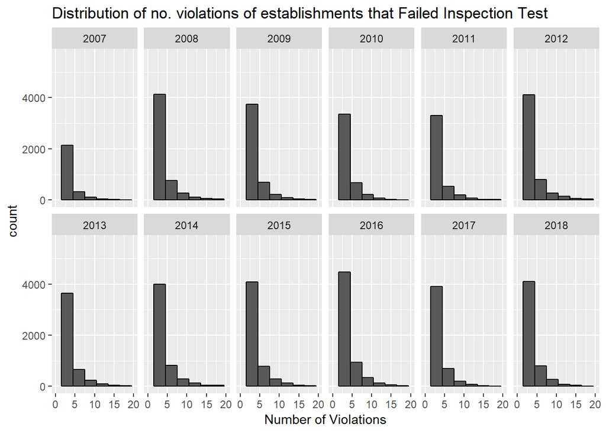

```r
finalviol %>% filter (ViolStatus=="Fail", year %in% c(2007,2008, 2009, 2010, 2011, 2012, 2013, 2014, 2015, 2016, 2017,2018))%>%

  ggplot(aes(n)) +

  geom_histogram (binwidth = 3, color = "black")+

  xlim(0, 20)+

  facet_wrap(.~year, ncol=6)+ xlab("Number of Violations")+

  ggtitle("Distribution of no. violations of establishments that Failed Inspection Test")
```

However, we see from the boxplot below that there is a wide spread in the number of violations, with some inspections detecting over 40 counts of violations!

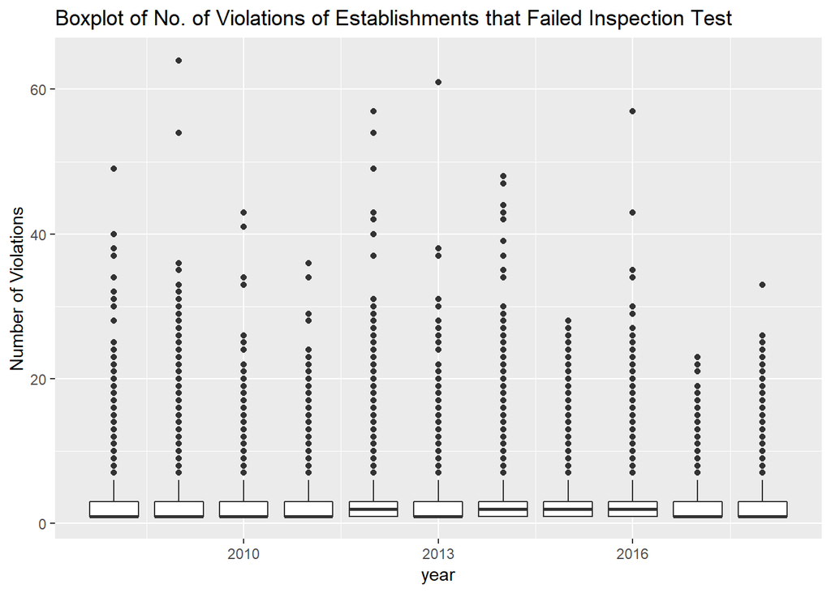

```r
finalviol %>% filter (year >2007 & ViolStatus=="Fail" ) %>%

  ggplot(aes(x=year, y = n, group=year))+

  geom_boxplot()+

  ylab("Number of Violations")+

  ggtitle("Boxplot of No. of Violations of Establishments that Failed Inspection Test")
```

Adding the total number of violations for each ViolStatus category, grouped by year:

```r
finalviol1 <- finalviol %>% filter (year !=2006 & ViolStatus=="Fail") %>%

  group_by(year) %>%

  summarize(total_no_violations_fail = sum(n))

finalviol2 <-finalviol %>% filter (year !=2006 & ViolStatus=="Pass") %>%

  group_by(year) %>%

  summarize(total_no_violations_pass = sum(n))

finalviol_number<- left_join(finalviol1,finalviol2)
finalviol_number<- finalviol_number %>%
  mutate(total_no_violations_diff = abs((total_no_violations_fail) - (total_no_violations_pass)))
```

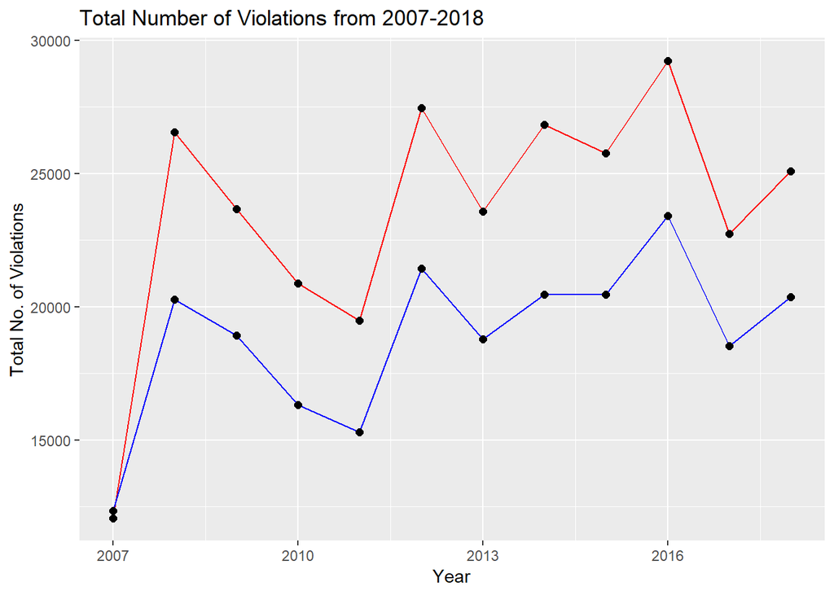

```r
finalviol_number %>%

  ggplot()+

  geom_line(aes (x=year, y = total_no_violations_fail), size =0.5, color = "red")+

  geom_point(aes (x=year, y= total_no_violations_fail), size = 2, color = "black")+

  geom_line(mapping=aes(x=year, y=total_no_violations_pass), size=0.5, color="blue")+

  geom_point(aes (x=year, y= total_no_violations_pass), size = 2, color = "black")+

  xlab("Year") +

  ylab(" Total No. of Violations ") +

  ggtitle("Total Number of Violations from 2007-2018")
```

This graph below shows the difference in the number of violations based on violation status.

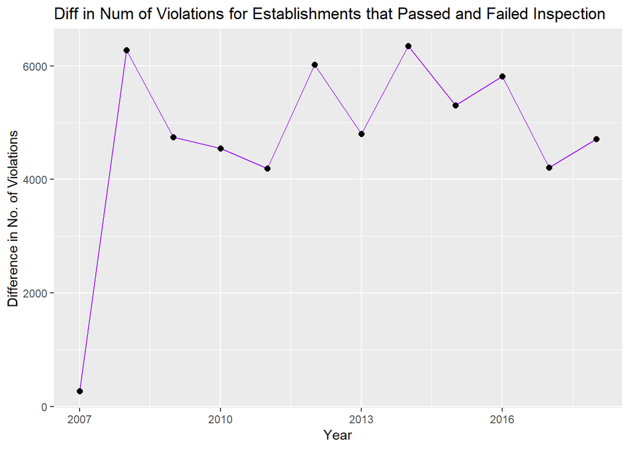

```r
finalviol_number %>%

  ggplot()+

  geom_line(aes (x=year, y = total_no_violations_diff), size =0.5, color = "purple")+

  geom_point(aes (x=year, y= total_no_violations_diff), size = 2, color = "black")+

  xlab("Year") +

  ylab(" Difference in No. of Violations ") +

  ggtitle("Diff in Num of Violations for Establishments that Passed and Failed Inspection")
```